# Analyzing Text: Sentiment Analysis

Unstructured Data Analytics, Fall 2023

# How can we detect if documents contain positive/negative feeling or specific emotion?

## First Step: Analyze Polarity with Lexicons

```r
# load initial packages
library(tidyverse)
library(tidytext)
```

First step: getting lexicons  
*For some, you have to download them: switch to the console to approve download*

```r
bing <- get_sentiments(lexicon = "bing")
afinn <- get_sentiments(lexicon = "afinn")
nrc <- get_sentiments(lexicon = "nrc")
```

### *Question: How do these sentiment lexicons vary in size and structure?*

Let’s take a look

```r
head(afinn)
```

| word | value |
| --- | --- |
| abandon | -2 |
| abandoned | -2 |
| abandons | -2 |
| abducted | -2 |
| abduction | -2 |
| abductions | -2 |

```r
summary(afinn)
```

```
##      word               value
##  Length:2477        Min.   :-5.0000
##  Class :character   1st Qu.:-2.0000
##  Mode  :character   Median :-2.0000
##                     Mean   :-0.5894
##                     3rd Qu.: 2.0000
##                     Max.   : 5.0000
```

Afinn is on a -5 to +5 scale.

```r
head(bing)
```

| word | sentiment |
| --- | --- |
| 2-faces | negative |
| abnormal | negative |
| abolish | negative |
| abominable | negative |
| abominably | negative |
| abominate | negative |

```r
#summary(bing)
```

Bing is a binary system with just positive & negative flags

```r
head(nrc)
```

| word | sentiment |
| --- | --- |
| abacus | trust |
| abandon | fear |
| abandon | negative |
| abandon | sadness |
| abandoned | anger |
| abandoned | fear |

```r
summary(nrc)
```

```
##      word            sentiment
##  Length:13872       Length:13872
##  Class :character   Class :character
##  Mode  :character   Mode  :character
```

```r
#how many distinct words are in NRC?
length(unique(nrc$word))
```

```
## [1] 6453
```

NRC contains emotions and positive/negative options. Each word can be listed multiple times, if the word is associated with multiple emotions

## Let’s keep our first focus on polarity

### Question: If we want to use the afinn data to score our stories, what general process should we use?

Tokenize the stories, join the stories and the lexicon, then aggregate by stories and perform a computation (sum, average, etc)

### Question: If we want to use the bing data to score our stories, what is different?

Same initial steps (tokenize & join), then aggregated by stories AND by the bing sentiment and count. We can’t just do a computation because we have “word” values instead of “number” values.

## Implementation

First, we have to get our text data ready

```r
#read in
dat <- read_csv("C:/Users/alanski/Downloads/UDA Fall 2023 Stories v3.csv")

#explore
glimpse(dat)
```

```
## Rows: 31
## Columns: 4
## $ id      <dbl> 1, 2, 3, 4, 5, 6, 7, 8, 9, 10, 11, 12, 13, 14, 15, 16, 17, 18,…
## $ story   <chr> "I have been fortunate enough to play  lacrosse with both of m…
## $ sport   <chr> "Lacrosse", "Football", "Baseball", "Tennis", "Baseball", "Bas…
## $ feeling <dbl> 5, 5, 4, 5, 5, 4, 1, 4, 5, 5, 4, 5, 5, 5, 4, 5, 5, 3, 5, 4, 4,…
```

- What columns do we have? *new column of “feeling”*
- Do we need to fix the sport column again? *yes, if we want to use it*
- Do you think we need to remove stopwords? *no, because they won’t be in the sentiment lexicons*

Cleanup, as needed. Prep appropriately for our next step

```r
dat_words <- dat %>% unnest_tokens(output = word,
                           input = story,
                           token = "words") %>%
  mutate(sport = tolower(sport))

dat_words
```

| id | sport | feeling | word |
| --- | --- | --- | --- |
| 1 | lacrosse | 5 | i |
| 1 | lacrosse | 5 | have |
| 1 | lacrosse | 5 | been |
| 1 | lacrosse | 5 | fortunate |
| 1 | lacrosse | 5 | enough |
| 1 | lacrosse | 5 | to |
| 1 | lacrosse | 5 | play |
| 1 | lacrosse | 5 | lacrosse |
| 1 | lacrosse | 5 | with |
| 1 | lacrosse | 5 | both |

[output cut: 5027 more lines]

Combine words with sentiment: afinn

```r
dat_afinn <- inner_join(dat_words, afinn, by = "word")
dat_afinn
```

| id | sport | feeling | word | value |
| --- | --- | --- | --- | --- |
| 1 | lacrosse | 5 | fortunate | 2 |
| 1 | lacrosse | 5 | cancelling | -1 |
| 1 | lacrosse | 5 | super | 3 |
| 2 | football | 5 | good | 3 |
| 2 | football | 5 | love | 3 |
| 3 | baseball | 4 | huge | 1 |
| 3 | baseball | 4 | collision | -2 |
| 4 | tennis | 5 | fame | 1 |
| 4 | tennis | 5 | cool | 1 |
| 4 | tennis | 5 | lost | -3 |

[output cut: 249 more lines]

### Question: What is the polarity of each story?

```r
dat_afinn %>%
  group_by(id) %>%
  summarize(total = sum(value, na.rm = T),
            avg = mean(value, na.rm = T))
```

| id | total | avg |
| --- | --- | --- |
| 1 | 4 | 1.3333333 |
| 2 | 6 | 3.0000000 |
| 3 | -1 | -0.5000000 |
| 4 | 5 | 0.7142857 |
| 5 | 6 | 0.8571429 |
| 6 | 13 | 1.0833333 |
| 7 | 3 | 0.3000000 |
| 8 | 7 | 1.7500000 |
| 9 | 31 | 1.6315789 |
| 10 | 27 | 2.0769231 |

[output cut: 21 more lines]

### What do the polarity numbers represent?

Total: Large positive or negative totals mean there are a lot of words that are positive or negative, or there are fewer words that are strongly positive or negative (like 20 words with a score of 1, or 5 words with a score of 4). It also means that any words of opposite polarity are “drowned out” by the the others. Smaller totals (closer to 0) are either because you don’t have very many emotion words to begin with (1 word scored at -3) or because you have a mix of positive and negative word scores that mostly cancel out.

Average: This is weighted by the number of emotion words. So it shows the positive/negative balance more fairly if you’re working with texts of very different lengths or of very different counts of sentiment words.

Medians would be another valuable metric to look at: what is your “middle” sentiment value?

Together, Total and Average can tell you more than either one can separately.

```r
#Let's implement BING

dat_bing <- inner_join(dat_words, bing, by = "word")

dat_bing <- dat_bing %>%
  count(id, sentiment) %>%
  pivot_wider(names_from = sentiment,
              values_from = n,
              values_fill = 0) %>%
  mutate(score = positive - negative,
         percent_positive = positive/(positive+negative))
```

Results are somewhat similar to AFINN but not the same. We have different numbers of words in the two lexicons and a different way to measure them.

## How might we graph polarity?

Bar plot, with story ID on the x axis and a value on the y axis, with color to indicate positive and negative (or positive, negative, and neutral)  
The same setup works for percent_positive, if we just tweak the column names and the ifelse values.

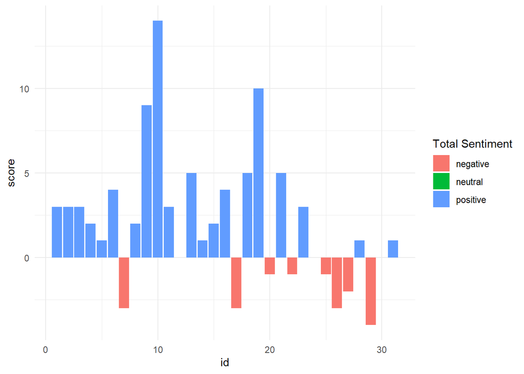

```r
dat_bing %>%
  ggplot(
          #set x and y
         aes(x = id, y = score,
             #fills in the bars with color
             #we have to create a new variable to evaluate +/-/neutral
             #this is one way to write it
             fill = ifelse(score > 0,
                           "positive",
                           ifelse(score < 0,
                                  "negative",
                                  "neutral")))) +
  geom_col() +
  #make it look nicer
  theme_minimal() +
  #this fixes the legend title, if you want to show it
  scale_fill_discrete(name = "Total Sentiment")
```

### Bonus graph

You can make this a point plot instead, which can be helpful if you want to see the neutral values more clearly.

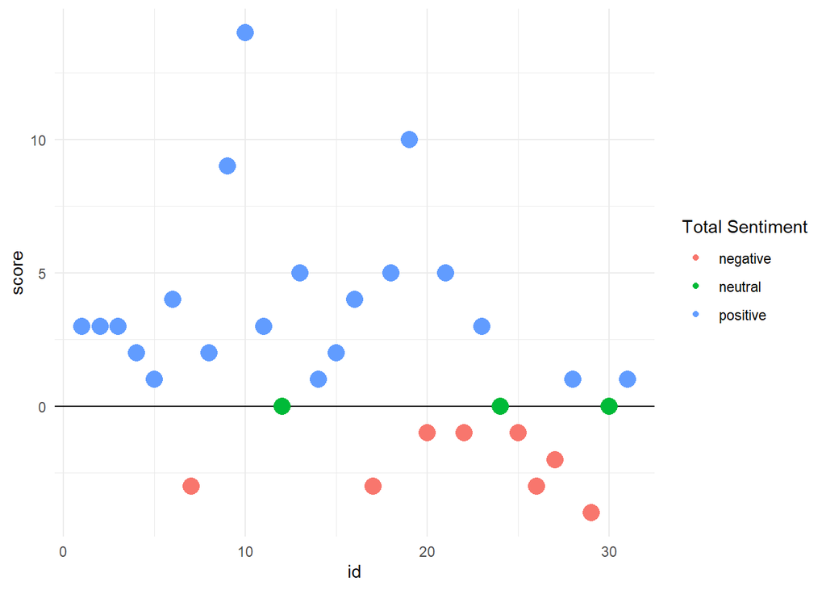

```r
dat_bing %>%
  ggplot(
         aes(x = id, y = score,
             #fill becomes color for points
             color = ifelse(score > 0,
                           "positive",
                           ifelse(score < 0,
                                  "negative",
                                  "neutral")),
             #this makes the points bigger: it is part of the AES
             size = 2)) +
  #I want to see the 0 line more cleary
  geom_hline(yintercept = 0) +
  #this one gets us the points
  geom_point() +
  theme_minimal() +
  scale_color_discrete(name = "Total Sentiment") +
  #this removes the size legend that will also show up
  scale_size_continuous(guide = "none")
```

Add titles, custom axis labels etc to make these better

## Which emotions are present in each story?

### Which emotion is the most prevalent? What is the mix like?

We have to use NRC to answer this – it’s the only option with emotions instead of only polarity.

```r
#which emotion is the most prevalent in each story?
#tall/long data is helpful for answering this question

inner_join(dat_words, nrc, by = "word") %>%
  count(id, sentiment) %>%

  #we just want the emotion categories, so we can take out "positive" and "negative"
  filter(!sentiment %in% c("positive", "negative")) %>%

  #this will get us the top emotion in each story.
  group_by(id) %>%
  slice_max(order_by = n, n = 1)
```

| id | sentiment | n |
| --- | --- | --- |
| 1 | trust | 3 |
| 2 | anticipation | 7 |
| 3 | anger | 2 |
| 4 | anticipation | 3 |
| 4 | joy | 3 |
| 4 | sadness | 3 |
| 5 | anticipation | 7 |
| 6 | joy | 9 |
| 7 | anger | 7 |
| 7 | sadness | 7 |

[output cut: 33 more lines]

```r
#what is the mix of emotions like in each story?
#wide data is helpful for answering this question, so we can see the range for each at the same time

#starts out the same
inner_join(dat_words, nrc, by = "word") %>%
  filter(!sentiment %in% c("positive", "negative")) %>%
  count(id, sentiment) %>%

  #change the shape
  pivot_wider(names_from = sentiment,
              values_from = n,
              values_fill = 0)
```

| id | anticipation | joy | trust | anger | disgust | fear | surprise | sadness |
| --- | --- | --- | --- | --- | --- | --- | --- | --- |
| 1 | 2 | 1 | 3 | 0 | 0 | 0 | 0 | 0 |
| 2 | 7 | 4 | 3 | 1 | 1 | 3 | 1 | 0 |
| 3 | 1 | 1 | 0 | 2 | 0 | 1 | 1 | 0 |
| 4 | 3 | 3 | 2 | 2 | 1 | 2 | 1 | 3 |
| 5 | 7 | 4 | 4 | 5 | 2 | 1 | 3 | 1 |
| 6 | 5 | 9 | 5 | 5 | 3 | 3 | 5 | 4 |
| 7 | 4 | 3 | 5 | 7 | 3 | 5 | 4 | 7 |
| 8 | 4 | 1 | 3 | 2 | 0 | 1 | 0 | 1 |
| 9 | 3 | 7 | 8 | 1 | 1 | 0 | 3 | 2 |
| 10 | 3 | 5 | 10 | 8 | 1 | 8 | 6 | 7 |

[output cut: 21 more lines]

RColorBrewer is a package that provides a variety of preset color palettes. You can look it up online to see palette names and the colors for it. Some palettes are accessible for people with colorblindness.

# What about context: issues like valence?

## Can we view sentiment at a higher level, beyond single words?

Yes, of course we can!

This capability lets us account (to some extent) for valence shifters.

### Implementing higher-level sentiment

The tidytext package is set up for word-level only. That means we have to shift to the `sentimentr` package.

Let’s find new sentiment values for each story, taking valence into consideration.  
We do NOT start with tidytext functions – we start with the raw data, and use functions from the new package (in combination with dplyr functions).

#### How can we easily check for example sentences or review the scoring more visually?

If you want to “check the work” done by the package this is a fun thing, but it doesn’t knits well. It’s more for your own exploration than for an analytical report. I have updated the code chunk to start with {r, eval = FALSE} so this file will still knit for you.

```r
#tokenize again
get_sentences(dat) %>%

  #this groups by id and aggregates, all at once
  #here or above, you could aggregate by sport instead of by id
  sentiment_by(by = c("id")) %>%

  #this opens a separate browser window so you can explore
  highlight()
```